# Whether Analysis

# 1. Load Data data = pd.read_csv('data.csv') # 2. Data Understanding data.info() data.describe() # 3. Data Cleaning data.drop_duplicates() data.fillna() # 4. EDA sns.barplot() sns.lineplot() # 5. Feature Selection X = data.drop('Target', axis=1) y = data['Target'] # 6. Train-Test Split from sklearn.model_selection import train_test_split X_train, X_test, y_train, y_test = train_test_split( X, y, test_size=0.2, random_state=42 ) # 7. Scaling (if required) from sklearn.preprocessing import StandardScaler scaler = StandardScaler() X_train = scaler.fit_transform(X_train) X_test = scaler.transform(X_test) # 8. Train Model from sklearn.ensemble import RandomForestClassifier model = RandomForestClassifier() model.fit(X_train, y_train) # 9. Prediction y_pred = model.predict(X_test) # 10. Evaluation from sklearn.metrics import accuracy_score accuracy_score(y_test, y_pred)

```python
import pandas as pd
import numpy as np
import seaborn as sns
import matplotlib.pyplot as plt
import plotly.express as px
```

## 1. Load Data

```python
df = pd.read_excel(
    r"C:\Users\nived\Downloads\archive (6)\india_weather_rainfall_data.xlsx"
)
```

```python
df.head()
```

|  | date_of_record | month | season | station_name | state | district | avg_temp | min_temp | max_temp | wind_speed | air_pressure | elevation | latitude | longitude | rainfall |
| --- | --- | --- | --- | --- | --- | --- | --- | --- | --- | --- | --- | --- | --- | --- | --- |
| 0 | 2021-01-02 | January | Winter | Gulmarg | JK | Baramulla | -2.2 | -6.6 | -0.8 | 2.2 | 1020.0 | 2652 | 34.05 | 74.4 | 0.1 |
| 1 | 2021-01-03 | January | Winter | Gulmarg | JK | Baramulla | -3.6 | -4.6 | -1.8 | 3.7 | 1019.5 | 2652 | 34.05 | 74.4 | 4.4 |
| 2 | 2021-01-04 | January | Winter | Gulmarg | JK | Baramulla | -3.0 | -4.5 | -1.1 | 2.1 | 1022.0 | 2652 | 34.05 | 74.4 | 2.3 |
| 3 | 2021-01-05 | January | Winter | Gulmarg | JK | Baramulla | -3.3 | -5.1 | -1.2 | 2.8 | 1015.6 | 2652 | 34.05 | 74.4 | 35.0 |
| 4 | 2021-01-06 | January | Winter | Gulmarg | JK | Baramulla | -3.9 | -8.3 | -1.0 | 3.4 | 1015.3 | 2652 | 34.05 | 74.4 | 25.5 |

## 2. Data Understanding

```python
df.info()
```

```
<class 'pandas.core.frame.DataFrame'>
RangeIndex: 970339 entries, 0 to 970338
Data columns (total 15 columns):
 #   Column          Non-Null Count   Dtype
---  ------          --------------   -----
 0   date_of_record  970339 non-null  datetime64[ns]
 1   month           970339 non-null  object
 2   season          970339 non-null  object
 3   station_name    970339 non-null  object
 4   state           970339 non-null  object
 5   district        970339 non-null  object
 6   avg_temp        970339 non-null  float64
 7   min_temp        926441 non-null  float64
 8   max_temp        859741 non-null  float64
 9   wind_speed      695895 non-null  float64
 10  air_pressure    665675 non-null  float64
 11  elevation       970339 non-null  int64
 12  latitude        970339 non-null  float64
 13  longitude       970339 non-null  float64
 14  rainfall        712785 non-null  float64
dtypes: datetime64[ns](1), float64(8), int64(1), object(5)
memory usage: 111.0+ MB
```

```python
df.describe()
```

|  | date_of_record | avg_temp | min_temp | max_temp | wind_speed | air_pressure | elevation | latitude | longitude | rainfall |
| --- | --- | --- | --- | --- | --- | --- | --- | --- | --- | --- |
| count | 970339 | 970339.000000 | 926441.000000 | 859741.000000 | 695895.000000 | 665675.000000 | 970339.000000 | 970339.000000 | 970339.000000 | 712785.000000 |
| mean | 2021-03-27 08:51:14.557655808 | 25.661709 | 20.647342 | 31.195383 | 9.432732 | 1009.437663 | 298.181018 | 20.793670 | 79.426826 | 5.267533 |
| min | 2015-01-01 00:00:00 | -10.400000 | -18.500000 | -5.600000 | 0.000000 | 922.600000 | 0.000000 | 7.983300 | 68.850000 | 0.000000 |
| 25% | 2019-03-07 00:00:00 | 23.100000 | 17.100000 | 28.500000 | 6.100000 | 1005.800000 | 16.000000 | 15.850000 | 75.400000 | 0.000000 |
| 50% | 2021-11-09 00:00:00 | 26.700000 | 22.400000 | 31.600000 | 8.400000 | 1009.800000 | 139.000000 | 21.616700 | 78.066700 | 0.000000 |
| 75% | 2023-06-24 00:00:00 | 29.100000 | 25.000000 | 34.400000 | 11.600000 | 1013.300000 | 436.000000 | 25.566700 | 82.716700 | 4.000000 |
| max | 2025-02-10 00:00:00 | 43.400000 | 36.600000 | 87.000000 | 66.600000 | 1036.500000 | 2652.000000 | 34.083300 | 95.383300 | 485.900000 |
| std | NaN | 5.438133 | 6.008171 | 5.464499 | 4.979263 | 5.292871 | 415.266215 | 6.328275 | 5.852512 | 14.444142 |

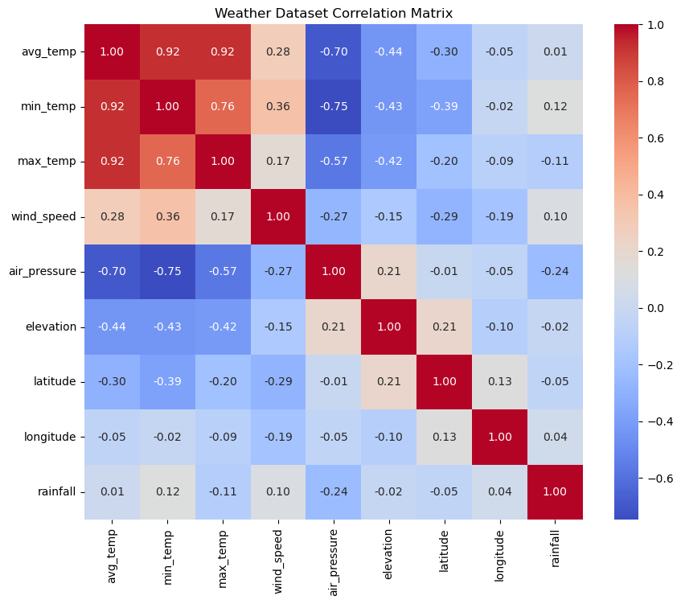

```python
num_cols = ['avg_temp','min_temp','max_temp','wind_speed','air_pressure','elevation','latitude','longitude','rainfall']
corr = df[num_cols].corr()

plt.figure(figsize=(10,8))

sns.heatmap(corr,annot=True,cmap='coolwarm',fmt='.2f')
plt.title('Weather Dataset Correlation Matrix')
plt.show()
```

### **Our target 'rainfall' is less correlated with others**

## 3. Data Cleaning

```python
df.isnull().sum()
```

```
date_of_record         0
month                  0
season                 0
station_name           0
state                  0
district               0
avg_temp               0
min_temp           43898
max_temp          110598
wind_speed        274444
air_pressure      304664
elevation              0
latitude               0
longitude              0
rainfall          257554
dtype: int64
```

### **There is lot of missing values are there need to fillna() with median of the relevant datas**

```python
cols = ['min_temp', 'max_temp', 'wind_speed','air_pressure', 'rainfall']  # The data Feature which need to fill

for col in cols:                                                         # using 'for' loop for filling values
    df[col] = df.groupby('station_name')[col] \
                .transform(lambda x: x.fillna(x.median()))
```

```python
df.isnull().sum()
```

```
date_of_record    0
month             0
season            0
station_name      0
state             0
district          0
avg_temp          0
min_temp          0
max_temp          0
wind_speed        0
air_pressure      0
elevation         0
latitude          0
longitude         0
rainfall          0
dtype: int64
```

## 4. EDA

### **When kerala get highest rainfall?**

```python
Kerala =df[df['state']=='KL']
Yearly = df.groupby(Kerala['date_of_record'].dt.year)
Rain = Kerala['rainfall']
```

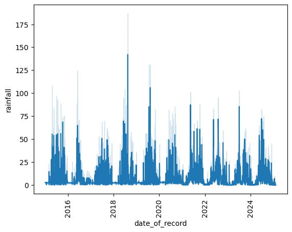

```python
sns.lineplot(x=Kerala['date_of_record'],y=Kerala['rainfall'],data=Kerala)
plt.xticks(rotation=90)
plt.show()
```

### **Based on the record Kerala get highest rainfall in 2018**

fig = px.scatter_map(df,lat=df['latitude'],lon=df['longitude'],color='rainfall',size='rainfall',hover_name='station_name',zoom=8,title='rainfall',height=799) fig.show()

## Statewise Average rainfall?

```python
state_dict = {
    'JK':'Jammu & Kashmir',
    'PB':'Punjab',
    'HP':'Himachal Pradesh',
    'HR':'Haryana',
    'CH':'Chandigarh',
    'UP':'Uttar Pradesh',
    'RJ':'Rajasthan',
    'DL':'Delhi',
    'AR':'Arunachal Pradesh',
    'WB':'West Bengal',
    'SK':'Sikkim',
    'AS':'Assam',
    'MP':'Madhya Pradesh',
    'BR':'Bihar',
    'ML':'Meghalaya',
    'NL':'Nagaland',
    'GJ':'Gujarat',
    'TR':'Tripura',
    'MN':'Manipur',
    'MZ':'Mizoram',
    'OR':'Odisha',
    'MH':'Maharashtra',
    'CT':'Chhattisgarh',
    'DD':'Daman & Diu',
    'KA':'Karnataka',
    'AP':'Andhra Pradesh',
    'GA':'Goa',
    'TN':'Tamil Nadu',
    'LD':'Lakshadweep',
    'AN':'Andaman & Nicobar',
    'KL':'Kerala',
    'PY':'Puducherry'
}

df['State_Name'] = df['state'].map(state_dict)     ## map the corresponding value from state_dict.act as lookup.
```

```python
state_rain = df.groupby('State_Name')['rainfall'].mean().sort_values(ascending=False).reset_index()
```

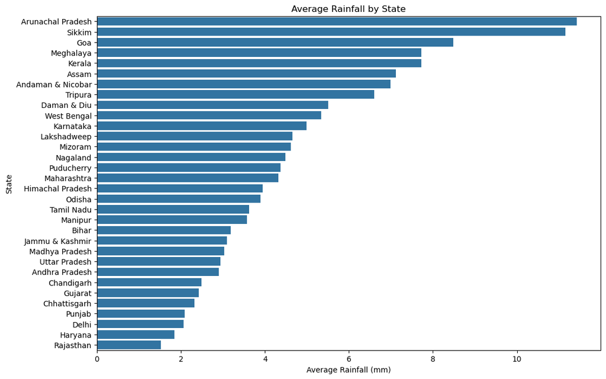

```python
plt.figure(figsize=(12,8))
sns.barplot(data=state_rain,x='rainfall',y='State_Name')

plt.title('Average Rainfall by State')
plt.xlabel('Average Rainfall (mm)')
plt.ylabel('State')
```

### **As per the record [**Arunachal Pradesh,Sikkim,Goa,Meghalaya,Kerala**] these 5 State meet highest Average rainfall**

## Average rainfall based on month

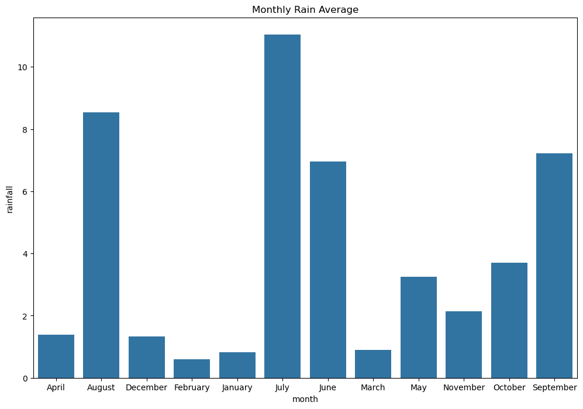

```python
monthly_rain = df.groupby('month')['rainfall'].mean().reset_index()
plt.figure(figsize=(12,8))
sns.barplot(data=monthly_rain,x='month',y='rainfall')
plt.title('Monthly Rain Average')
plt.show()
```

```python
Yearly_rain = df.groupby(df['date_of_record'].dt.year)['rainfall'].sum().reset_index()
```

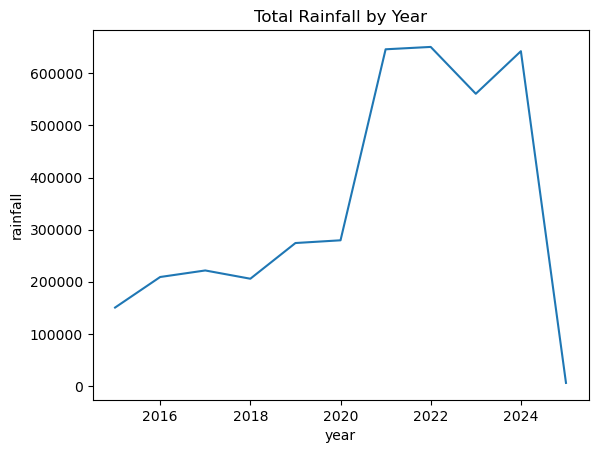

```python
sns.lineplot(data=Yearly_rain,x='date_of_record',y='rainfall')
plt.xlabel('year')
plt.ylabel('rainfall')
plt.title('Total Rainfall by Year')
plt.show()
```

### **Heavy rainfall in 2021,2022,2024**

```python
from ydata_profiling import ProfileReport
```

```python
report = ProfileReport(Kerala)
```

```python
report
```

[interactive chart not shown]

## 5.Feature Selection

```python
X = df.select_dtypes(include=['int64', 'float64']).drop('rainfall', axis=1)   # We mention dtype because of the easy scaling purpose
y = df['rainfall']
```

## 6. train_test_split

```python
from sklearn.model_selection import train_test_split
```

```python
X_train,X_test,y_train,y_test = train_test_split(X,y,test_size=0.3,random_state=0)
```

## 7. Scaling

```python
from sklearn.preprocessing import StandardScaler
```

```python
scalar = StandardScaler()
X_train = scalar.fit_transform(X_train)
X_test = scalar.transform(X_test)
```

## 8. Train Model

### Linear Regression

```python
from sklearn.linear_model import LinearRegression
```

```python
LRmodel = LinearRegression()
LRmodel.fit(X_train,y_train)
```

```
LinearRegression()
```

## Random Forest Regression

```python
from sklearn.ensemble import RandomForestRegressor
```

```python
RFRmodel = RandomForestRegressor()
RFRmodel.fit(X_train,y_train)
```

```
RandomForestRegressor()
```

```python
df['rainfall'].describe()
```

```
count    970339.000000
mean          3.964113
std          12.574856
min           0.000000
25%           0.000000
50%           0.000000
75%           2.000000
max         485.900000
Name: rainfall, dtype: float64
```

## Decision Tree Regression

```python
from sklearn.tree import DecisionTreeRegressor
```

```python
dt = DecisionTreeRegressor(random_state=42)
dt.fit(X_train,y_train)
```

```
DecisionTreeRegressor(random_state=42)
```

## ExtraTreesRegressor

```python
from sklearn.ensemble import ExtraTreesRegressor
```

```python
et = ExtraTreesRegressor(
    n_estimators=100,
    random_state=42
)
et.fit(X_train, y_train)
```

```
ExtraTreesRegressor(random_state=42)
```

## 9. Prediction

```python
y_pred = LRmodel.predict(X_test)
```

### Random Forest Regression

```python
y_pred1 = RFRmodel.predict(X_test)
```

## Decision Tree

```python
y_pred2 = dt.predict(X_test)
```

## Extra Tree Regressor

```python
y_pred3 = et.predict(X_test)
```

## 10. Evaluating

```python
from sklearn.metrics import mean_absolute_error,mean_squared_error,r2_score
```

```python
mae = mean_absolute_error(y_test,y_pred)
mse = mean_squared_error(y_test,y_pred)
rmse= mean_squared_error(y_test,y_pred) ** 0.5                           #  RMSE = √(MSE)
r2 = r2_score(y_test,y_pred)


print("MAE :", mae)
print("MSE :", mse)
print("RMSE:", rmse)
print("R2 Score:", r2)
```

```
MAE : 5.425571265191926
MSE : 141.95192255577564
RMSE: 11.914357832286877
R2 Score: 0.11434851665168255
```

### Random Forest Regression

```python
from sklearn.metrics import mean_absolute_error,mean_squared_error,r2_score
```

```python
RFRmae = mean_absolute_error(y_test,y_pred1)
RFRmse = mean_squared_error(y_test,y_pred1)
RFRrmse = mean_squared_error(y_test,y_pred1) ** 0.5
RFRr2 = r2_score(y_test,y_pred1)

print("MAE :", RFRmae)
print("MSE :", RFRmse)
print("RMSE:", RFRrmse)
print("R2 Score:", RFRr2)
```

```
MAE : 3.682792753160429
MSE : 99.37765131942191
RMSE: 9.968833999993274
R2 Score: 0.3799734253818541
```

## Decision Tree Regression

```python
dtmae = mean_absolute_error(y_test,y_pred2)
dtmse = mean_squared_error(y_test,y_pred2)
dtrmse = mean_squared_error(y_test,y_pred2) ** 0.5
dtr2 = r2_score(y_test,y_pred2)

print("MAE :", dtmae)
print("MSE :", dtmse)
print("RMSE:", dtrmse)
print("R2 Score:", dtr2)
```

```
MAE : 4.510784843340915
MSE : 195.3197812160252
RMSE: 13.975685357649736
R2 Score: -0.21861860584010273
```

#### **Test R² = -0.219**

### **The model overfit severely and failed to generalize.**

## Extra Tree Regression

```python
from sklearn.metrics import mean_absolute_error,mean_squared_error,r2_score

etmae = mean_absolute_error(y_test,y_pred3)
etmse = mean_squared_error(y_test,y_pred3)
etrmse = mean_squared_error(y_test,y_pred3) ** 0.5
etr2 = r2_score(y_test,y_pred3)

print("MAE :", etmae)
print("MSE :", etmse)
print("RMSE:", etrmse)
print("R2 Score:", etr2)
```

```
MAE : 3.570567215645975
MSE : 99.06953003011002
RMSE: 9.953367773277044
R2 Score: 0.3818958232755709
```

## Conclusion

****This Weather Analysis project explored a large-scale weather dataset containing approximately 970,000 records collected across multiple states, districts, weather stations, and seasons in India.****

****The project involved data cleaning, handling missing values, exploratory data analysis, feature correlation analysis, and rainfall prediction using machine learning regression techniques. Significant missing values were identified in important weather attributes such as rainfall, wind speed, air pressure, and temperature-related variables, which were addressed during preprocessing.*****

****Overall, this project successfully demonstrates the complete Data Science workflow, including data preprocessing, exploratory analysis, feature preparation, model training, and performance evaluation. Future improvements can include advanced ensemble models such as XGBoost, LightGBM, or CatBoost, feature engineering, hyperparameter optimization, and deployment through an interactive dashboard.****